# Econ 144 Project 2: Forecasting Bitcoin Stock Price

Yucong Chen, Yijia He, Anqi Li

Due 2/23/2023

# I. Introduction

In this project, we fit a forecasting model with trend, seasonal dummies, and cycles. The data we use is the stock price of Bitcoin, which is an innovative payment network and a new kind of money. Bitcoin is a very high-risk investment because it’s a volatile asset. That means that Bitcoin values may rise or fall dramatically in value over a very short period—even as quickly as a few hours or days. The Bitcoin network of miners makes money from Bitcoin by successfully validating blocks and being rewarded. The dataset includes the daily stock price (Open, High, Low, Close, Adj Close, Volume) from Sep.17th 2014 to May.5th 2022.

# II. Results

1. Produce a time-series plot of your data including the respective ACF and PACF plots.

```r
BTC <- read_csv("BTC-USD.csv")
```

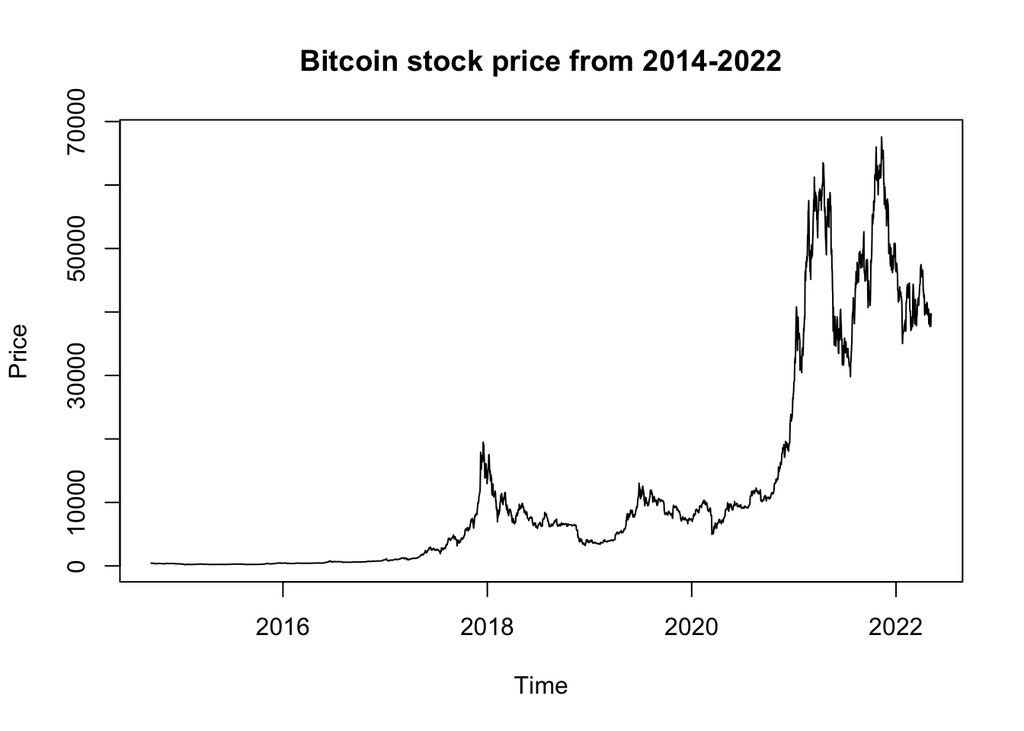

```r
BTC_ts = ts(BTC$`Adj Close`, start=2014.71, freq=365)
plot(BTC_ts, main = "Bitcoin stock price from 2014-2022", ylab="Price")
```

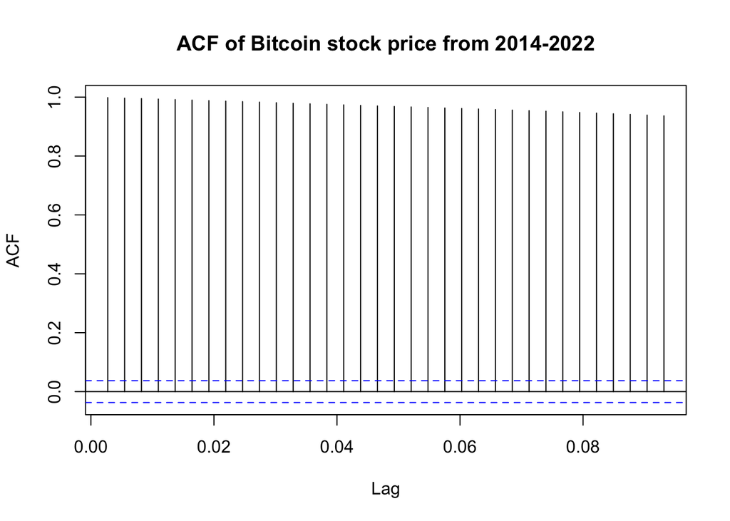

```r
acf(BTC_ts, main="ACF of Bitcoin stock price from 2014-2022")
```

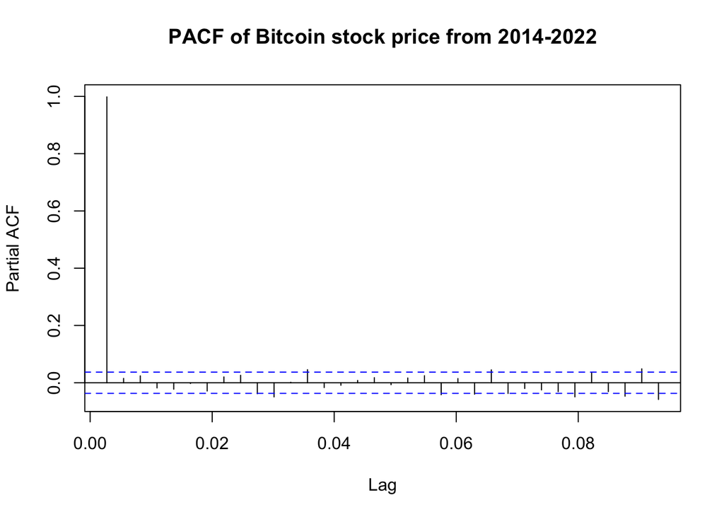

```r
pacf(BTC_ts, main="PACF of Bitcoin stock price from 2014-2022")
```

The time series plot has a clear upward trend and is not covariance stationary. The stock price is lowest at the beginning and reaches its peak in around the end of 2021. We still need to analyze in details to see if seasonality and cycles exist. Moreover, ACF slowly decays (to 0) and there is one spike for PACF, suggesting maybe an AR(1) model.

2. Plot the stl decomposition plot of your data, and discuss the results.

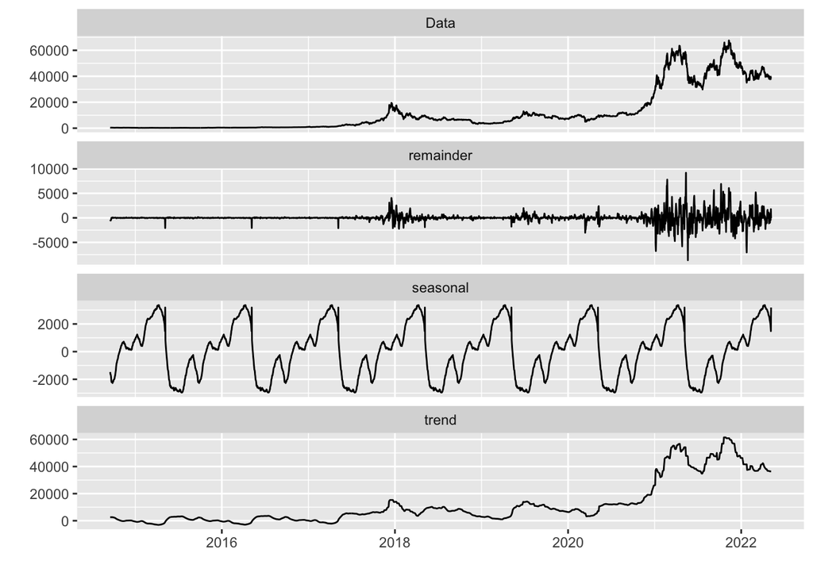

```r
BTC_ts %>% stl(t.window=13, s.window="periodic", robust=TRUE) %>% autoplot()
```

We can see trend since the trend component slowly increases from 2014 to 2020, increases faster and reaches the spikes after 2020, and decreases at the end of 2021. There are also strong seasonal components because the pattern shows that the stock price increases at the beginning of the year, decreases strongly later, then gradually increases with some minor decreases. The remainder is quite stable at first, but fluctuates around 2018. Starting from 2021, the remainder becomes very volatile and suggests that some cycles present.

3. Fit a model that includes, trend, seasonality and cyclical components. Make sure to discuss your model in detail.

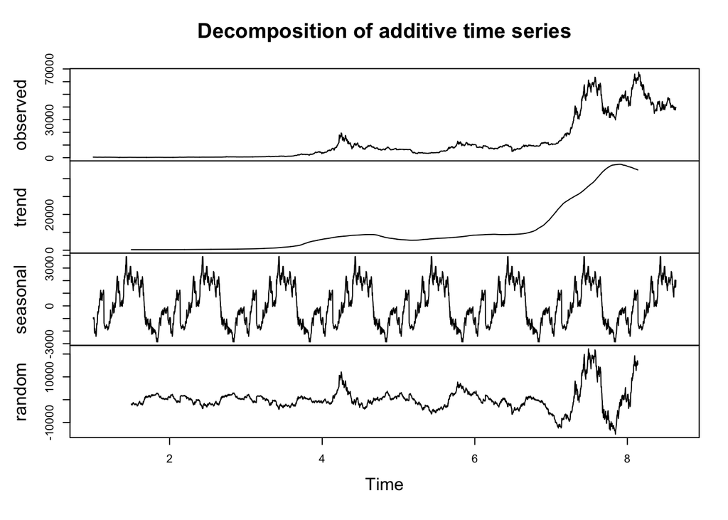

```r
# Additive decomposition
dcmp = decompose(ts(BTC_ts, frequency=365), "additive")
plot(dcmp)
```

```r
# Our first model
fit <- tslm(BTC_ts ~ dcmp$trend + dcmp$season)
summary(fit)
```

```
##
## Call:
## tslm(formula = BTC_ts ~ dcmp$trend + dcmp$season)
##
## Residuals:
##    Min     1Q Median     3Q    Max
## -16709  -1973    -38   1784  21155
##
## Coefficients:
##               Estimate Std. Error t value Pr(>|t|)
## (Intercept) -4.306e+02  1.259e+02  -3.422 0.000632 ***
## dcmp$trend   1.043e+00  7.418e-03 140.545  < 2e-16 ***
## dcmp$season  1.012e+00  6.168e-02  16.403  < 2e-16 ***
## ---
## Signif. codes:  0 '***' 0.001 '**' 0.01 '*' 0.05 '.' 0.1 ' ' 1
##
## Residual standard error: 4860 on 2421 degrees of freedom
##   (364 observations deleted due to missingness)
## Multiple R-squared:  0.8915, Adjusted R-squared:  0.8914
## F-statistic:  9946 on 2 and 2421 DF,  p-value: < 2.2e-16
```

We first do an additive decomposition, and it shows mostly similar results from the stl decomposition in (b), except that the seasonal component here is more ragged. The trend plot is more smooth and the trend does not show the huge fluctuations between 2020 to 2022. The trend only captures one drop at the end.

We use a linear regression plus the trend and seasonality in the additive decomposition as our first model. We can see that the p value of the intercept and the two predictors, dcmp$trend and dcmp$season, are both very small, meaning that the two predictors are statistically significant. The $R^2$ of 0.8915 also shows that the model captures most data in the set and performs pretty well. The F-statistics of the model is significant as well because the p-value is very small. Therefore, the model is a valid model.

5. Plot the respective residuals vs. fitted values and discuss your observations.

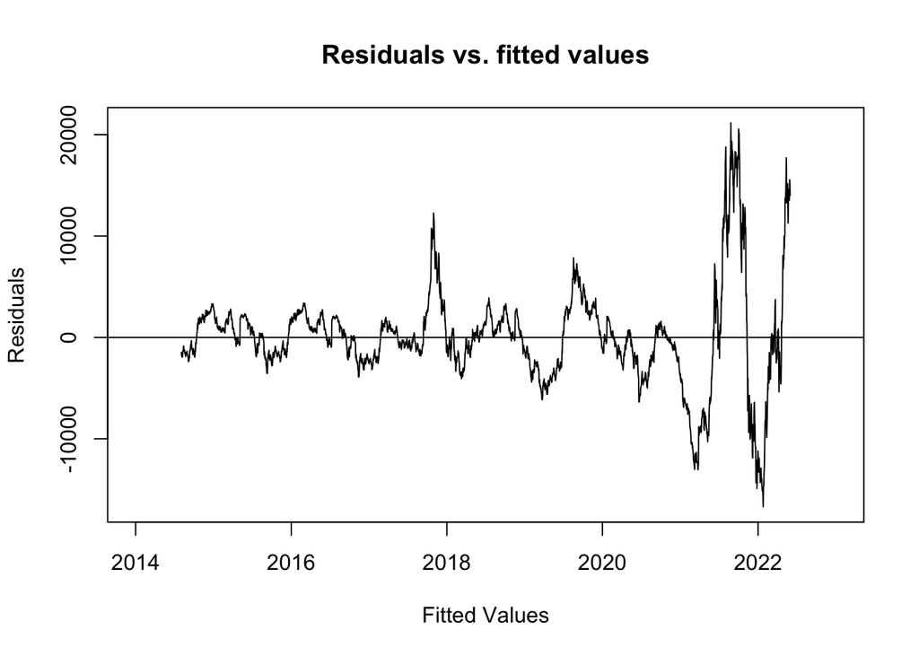

```r
t <- seq(2014, 2023, length=length(BTC_ts))
plot(t, fit$residuals, main="Residuals vs. fitted values",
     ylab="Residuals", type='l', xlab="Fitted Values")
abline(0,0)
```

Residuals show a yearly cyclic pattern that is very obvious from 2014 to 2021. There is a small peak at the end of 2017, and the residuals after 2021 become larger in absolute value. This shows that our model does not capture the fluctuations after 2021 very well when there was a huge increase in stock price at that time because of the crypto exchange trend that happened at that time.

6. Plot the ACF and PACF of the respective residuals and interpret the plots.

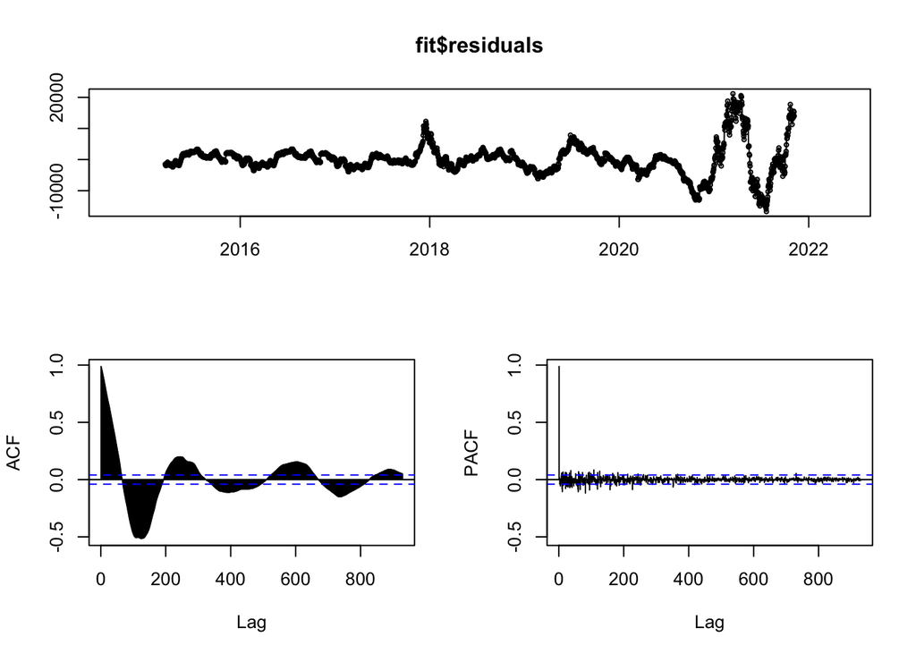

```r
tsdisplay(fit$residuals)
```

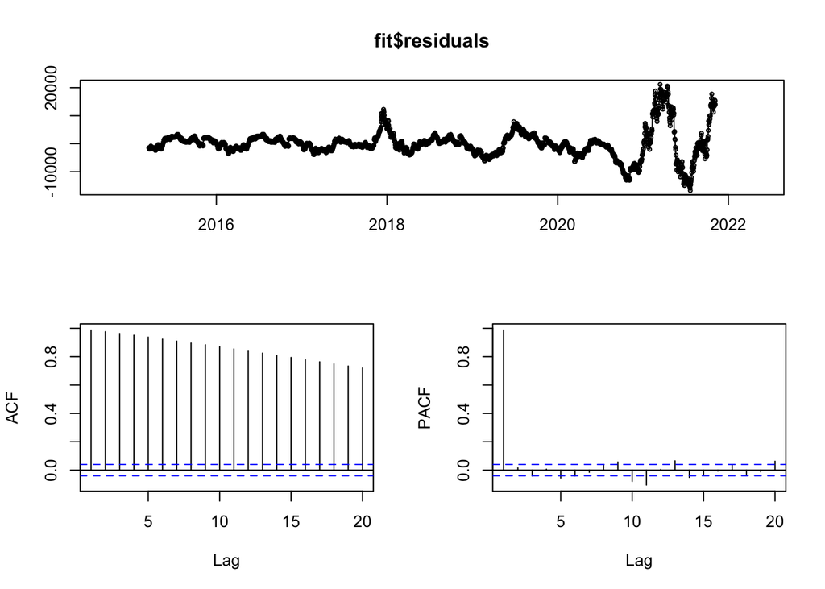

```r
tsdisplay(fit$residuals, lag.max = 20)
```

We see that ACF slowly decays to 0 and there is one significant spike in PACF, suggesting there might be an AR(1) present in residuals.

7. Plot the respective CUSUM and interpret the plot.

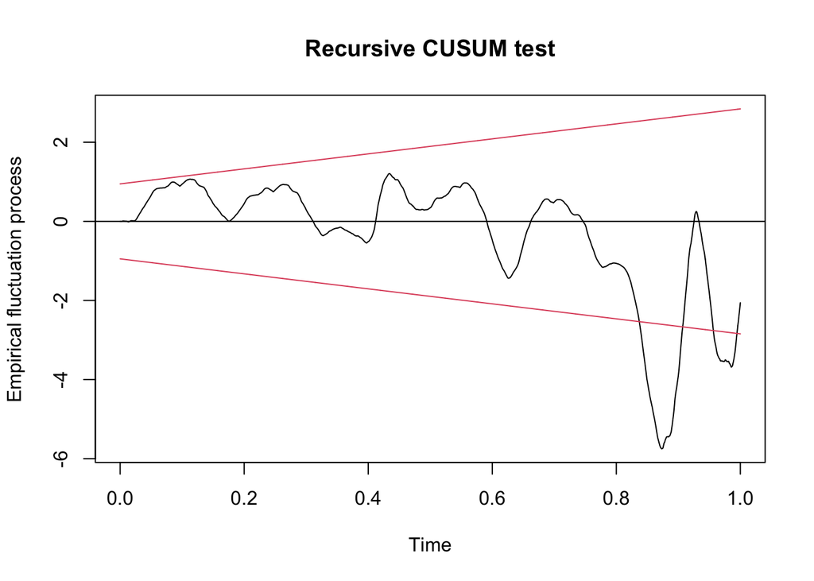

```r
plot(efp(fit$residuals ~ 1, type="Rec-CUSUM"))
```

The CUSUM chart plots the cumulative sums of the deviations of the sample values from a target value. A segment of the CUSUM chart with an upward slope indicates a period where the values tend to be above average. Likewise, a segment with a downward slope indicates a period of time where the values tend to be below the average. Our CUSUM plot shows that there is some structural change in our residuals, as they surpass the red lines.

8. For your model, discuss the associated diagnostic statistics.

All statistics show that there are some data changes after 2021 that our model did not capture completely. These lead to the increase, structural changes, and potential patterns in our residuals. However, our model does pretty much capture the seasonality and especially everything before 2020. This is also helpful because cyclic patterns suggest that these patterns may repeat in the future when there are fewer unexpected events like Covid.

1. Use your model to forecast 12-steps ahead. Your forecast should include the respective error bands.

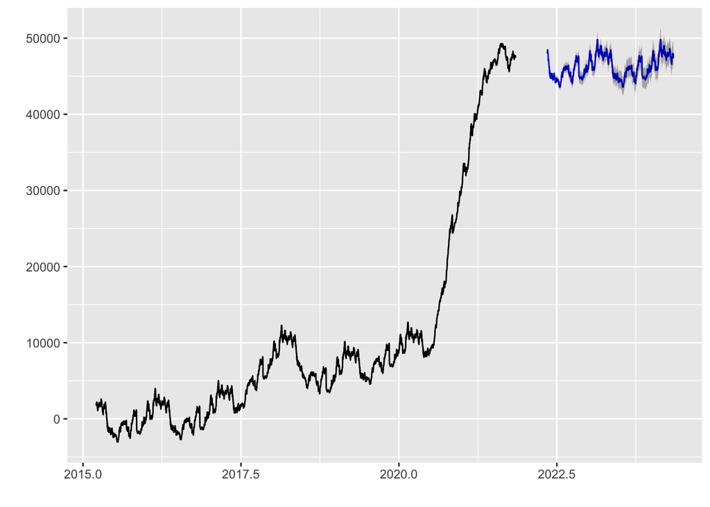

```r
fit$fitted.values %>% forecast(method="naive",) %>% autoplot()
```

We can see the forecast lingers between 44,000 to 50,000 and exhibits cycles.

10. Compare your forecast from (i) to the 12-steps ahead forecasts from ARIMA model. Which model performs best in terms of MAPE?

```r
# Arima
ar1=Arima(BTC_ts,order=c(1,0,1))
summary(ar1)
```

```
## Series: BTC_ts
## ARIMA(1,0,1) with non-zero mean
##
## Coefficients:
##          ar1      ma1      mean
##       0.9993  -0.0264  12135.93
## s.e.  0.0008   0.0190  15633.16
##
## sigma^2 = 630461:  log likelihood = -22573.53
## AIC=45155.07   AICc=45155.08   BIC=45178.8
##
## Training set error measures:
##                    ME     RMSE      MAE        MPE     MAPE       MASE
## Training set 14.23623 793.5882 344.1639 -0.7052265 2.887295 0.03959912
##                      ACF1
## Training set 6.952704e-05
```

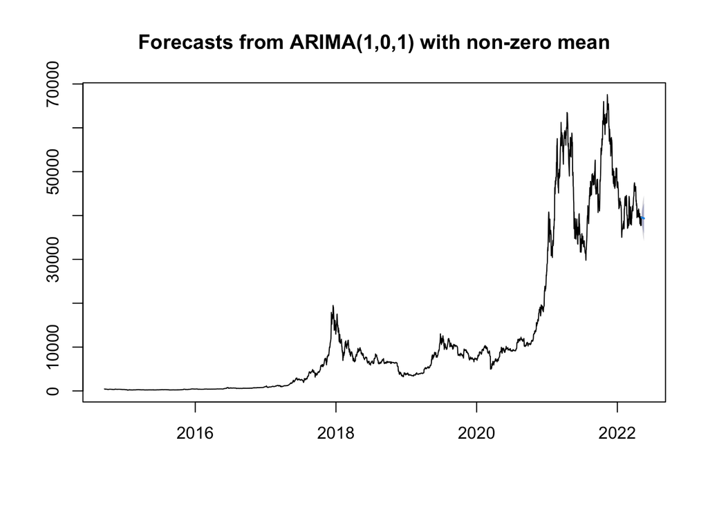

```r
plot(forecast(ar1, h=12))
```

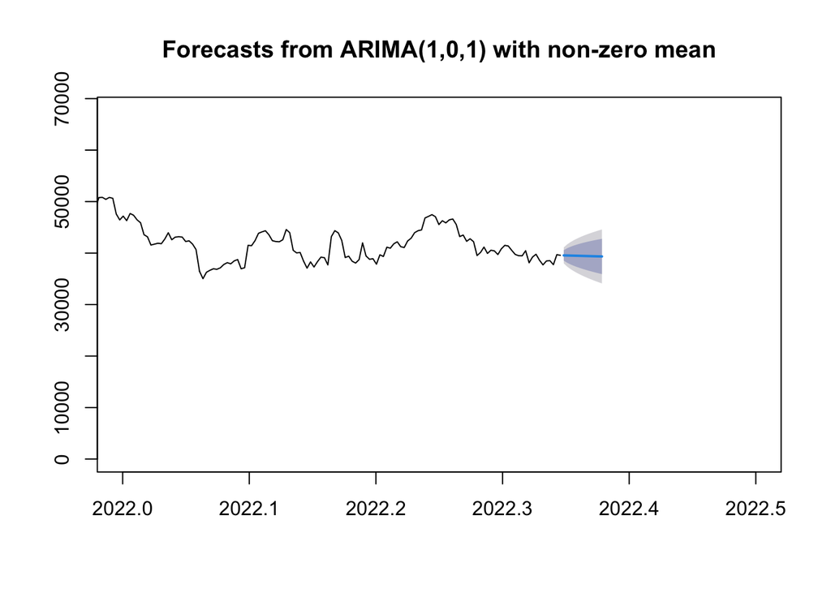

```r
plot(forecast(ar1, h=12), xlim = c(2022,2022.5))
```

```r
print(forecast(ar1, h=12))
```

```
##           Point Forecast    Lo 80    Hi 80    Lo 95    Hi 95
## 2022.3484       39551.64 38534.07 40569.21 37995.40 41107.88
## 2022.3511       39532.91 38113.18 40952.65 37361.61 41704.21
## 2022.3538       39514.20 37783.73 41244.66 36867.68 42160.71
## 2022.3566       39495.49 37502.50 41488.49 36447.47 42543.52
## 2022.3593       39476.81 37252.35 41701.26 36074.79 42878.82
## 2022.3621       39458.13 37024.39 41891.86 35736.05 43180.20
## 2022.3648       39439.46 36813.33 42065.60 35423.14 43455.79
## 2022.3675       39420.81 36615.68 42225.95 35130.73 43710.90
## 2022.3703       39402.17 36429.02 42375.33 34855.13 43949.22
## 2022.3730       39383.55 36251.59 42515.51 34593.63 44173.47
## 2022.3758       39364.94 36082.04 42647.83 34344.18 44385.69
## 2022.3785       39346.34 35919.34 42773.33 34105.20 44587.47
```

```r
# MAPE of our first model
number = na.omit(abs(fit$residuals))
sum(number/BTC_ts)/2788 # 2788 is the number of observations of stock price
```

```
## [1] 1.205276
```

11. Combine the forecasts and comment on the MAPE from this forecasts vs., the individual ones.

```r
# Combine forecasts
combination <- tslm(BTC_ts ~ dcmp$trend + dcmp$season + ar1$residuals)
summary(combination)
```

```
##
## Call:
## tslm(formula = BTC_ts ~ dcmp$trend + dcmp$season + ar1$residuals)
##
## Residuals:
##      Min       1Q   Median       3Q      Max
## -16113.1  -1951.0    -36.6   1780.9  20551.7
##
## Coefficients:
##                 Estimate Std. Error t value Pr(>|t|)
## (Intercept)   -4.247e+02  1.255e+02  -3.385 0.000723 ***
## dcmp$trend     1.041e+00  7.409e-03 140.469  < 2e-16 ***
## dcmp$season    1.002e+00  6.154e-02  16.281  < 2e-16 ***
## ar1$residuals  5.297e-01  1.318e-01   4.020    6e-05 ***
## ---
## Signif. codes:  0 '***' 0.001 '**' 0.01 '*' 0.05 '.' 0.1 ' ' 1
##
## Residual standard error: 4844 on 2420 degrees of freedom
##   (364 observations deleted due to missingness)
## Multiple R-squared:  0.8922, Adjusted R-squared:  0.8921
## F-statistic:  6677 on 3 and 2420 DF,  p-value: < 2.2e-16
```

```r
# MAPE of this forecast
number2 <- na.omit(abs(combination$residuals))
sum(number2/BTC_ts)/2788 # 2788 is the number of observations of stock price
```

```
## [1] 1.195377
```

We see that this forecast has a slightly higher $R^2$ value of 0.8922 and a slightly lower MAPE of 1.195377, so this forecast of combination is better than any individual models. The coefficients in this new model is also statistically significant, with very small p values. The F statistics also has a very small p vlaue, showing that this model is valid.

12. Fit an appropriate VAR model using your two variables. Make sure to show the relevant plots and discuss your results from the fit.

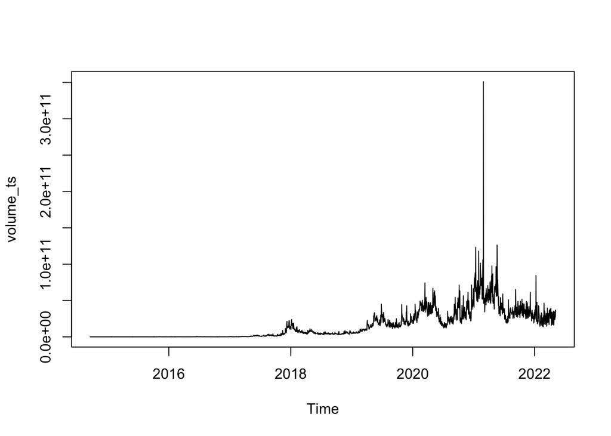

```r
volume_ts = ts(BTC$Volume, start=2014.71, freq=365)
plot(volume_ts)
```

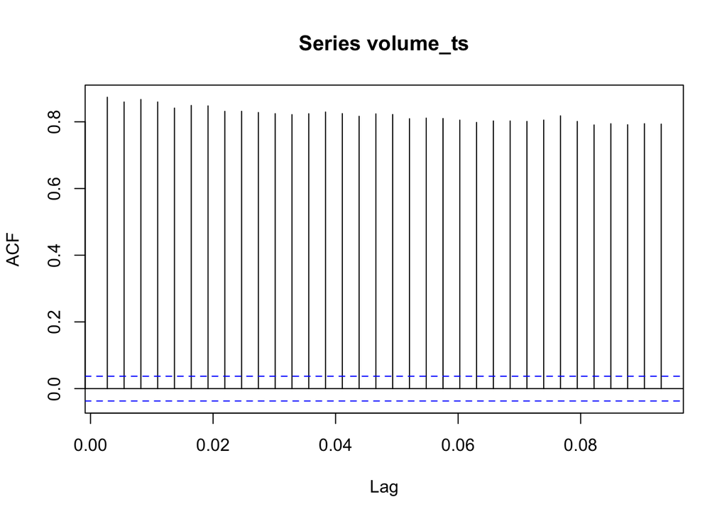

```r
acf(volume_ts)
```

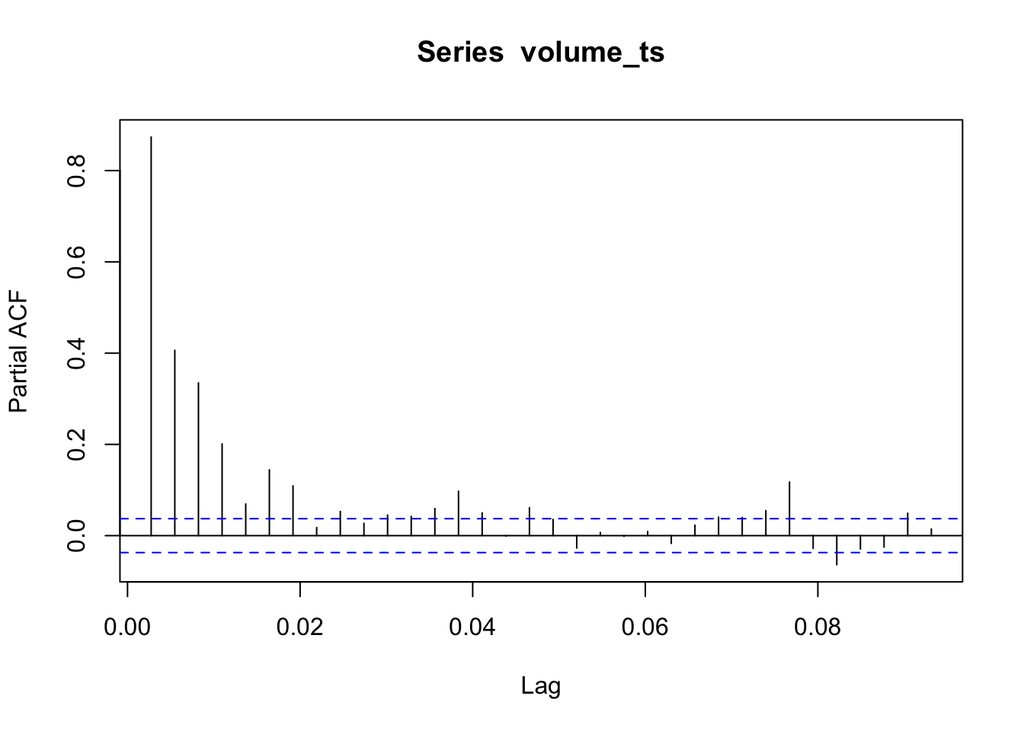

```r
pacf(volume_ts)
```

```r
y = cbind(BTC_ts, volume_ts)
y_tot = data.frame(y)
VARselect(y_tot, lag.max=10)
```

```
## $selection
## AIC(n)  HQ(n)  SC(n) FPE(n)
##     10     10      8     10
##
## $criteria
##                   1            2            3            4            5
## AIC(n) 5.926701e+01 5.912874e+01 5.901584e+01 5.897944e+01 5.897516e+01
## HQ(n)  5.927164e+01 5.913645e+01 5.902663e+01 5.899332e+01 5.899212e+01
## SC(n)  5.927982e+01 5.915008e+01 5.904572e+01 5.901786e+01 5.902212e+01
## FPE(n) 5.487026e+25 4.778431e+25 4.268271e+25 4.115726e+25 4.098155e+25
##                   6            7            8            9           10
## AIC(n) 5.894165e+01 5.892773e+01 5.891878e+01 5.891725e+01 5.890580e+01
## HQ(n)  5.896169e+01 5.895085e+01 5.894499e+01 5.894654e+01 5.893817e+01
## SC(n)  5.899715e+01 5.899176e+01 5.899136e+01 5.899836e+01 5.899545e+01
## FPE(n) 3.963101e+25 3.908295e+25 3.873496e+25 3.867569e+25 3.823525e+25
```

```r
y_model = VAR(y_tot, p=3)
summary(y_model)
```

```
##
## VAR Estimation Results:
## =========================
## Endogenous variables: BTC_ts, volume_ts
## Deterministic variables: const
## Sample size: 2785
## Log Likelihood: -90062.015
## Roots of the characteristic polynomial:
## 0.9994 0.9374 0.578 0.578 0.159 0.159
## Call:
## VAR(y = y_tot, p = 3)
##
##
## Estimation results for equation BTC_ts:
## =======================================
## BTC_ts = BTC_ts.l1 + volume_ts.l1 + BTC_ts.l2 + volume_ts.l2 + BTC_ts.l3 + volume_ts.l3 + const
##
##                Estimate Std. Error t value Pr(>|t|)
## BTC_ts.l1     9.760e-01  1.893e-02  51.558  < 2e-16 ***
## volume_ts.l1  1.693e-09  1.731e-09   0.978  0.32800
## BTC_ts.l2     1.094e-02  2.644e-02   0.414  0.67910
## volume_ts.l2 -5.883e-09  1.809e-09  -3.251  0.00116 **
## BTC_ts.l3     9.949e-03  1.897e-02   0.524  0.60010
## volume_ts.l3  6.993e-09  1.731e-09   4.040 5.48e-05 ***
## const         1.014e+01  1.937e+01   0.523  0.60080
## ---
## Signif. codes:  0 '***' 0.001 '**' 0.01 '*' 0.05 '.' 0.1 ' ' 1
##
##
## Residual standard error: 791.5 on 2778 degrees of freedom
## Multiple R-Squared: 0.9977,  Adjusted R-squared: 0.9977
## F-statistic: 2.041e+05 on 6 and 2778 DF,  p-value: < 2.2e-16
##
##
## Estimation results for equation volume_ts:
## ==========================================
## volume_ts = BTC_ts.l1 + volume_ts.l1 + BTC_ts.l2 + volume_ts.l2 + BTC_ts.l3 + volume_ts.l3 + const
##
##                Estimate Std. Error t value Pr(>|t|)
## BTC_ts.l1    -2.049e+05  1.968e+05  -1.041 0.297979
```

[output cut: 10 more lines]

```
## Residual standard error: 8.23e+09 on 2778 degrees of freedom
## Multiple R-Squared: 0.8291,  Adjusted R-squared: 0.8288
## F-statistic:  2247 on 6 and 2778 DF,  p-value: < 2.2e-16
##
##
##
## Covariance matrix of residuals:
##               BTC_ts  volume_ts
## BTC_ts     6.265e+05 -4.156e+11
## volume_ts -4.156e+11  6.773e+19
##
## Correlation matrix of residuals:
##             BTC_ts volume_ts
## BTC_ts     1.00000  -0.06381
## volume_ts -0.06381   1.00000
```

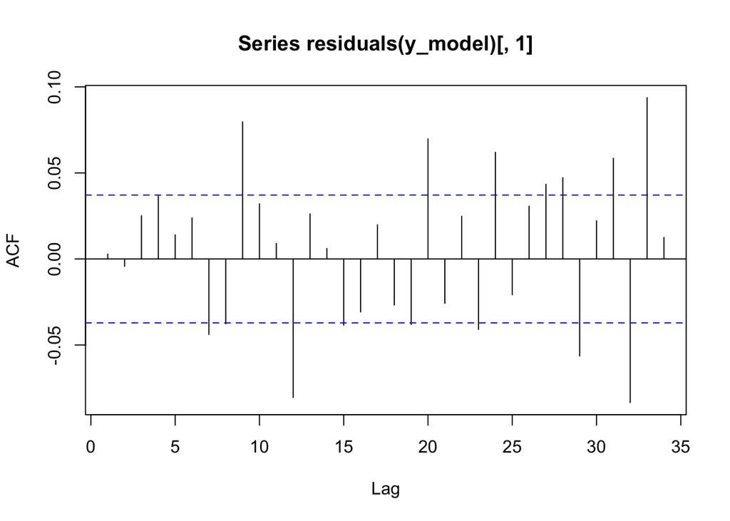

```r
acf(residuals(y_model)[,1])
```

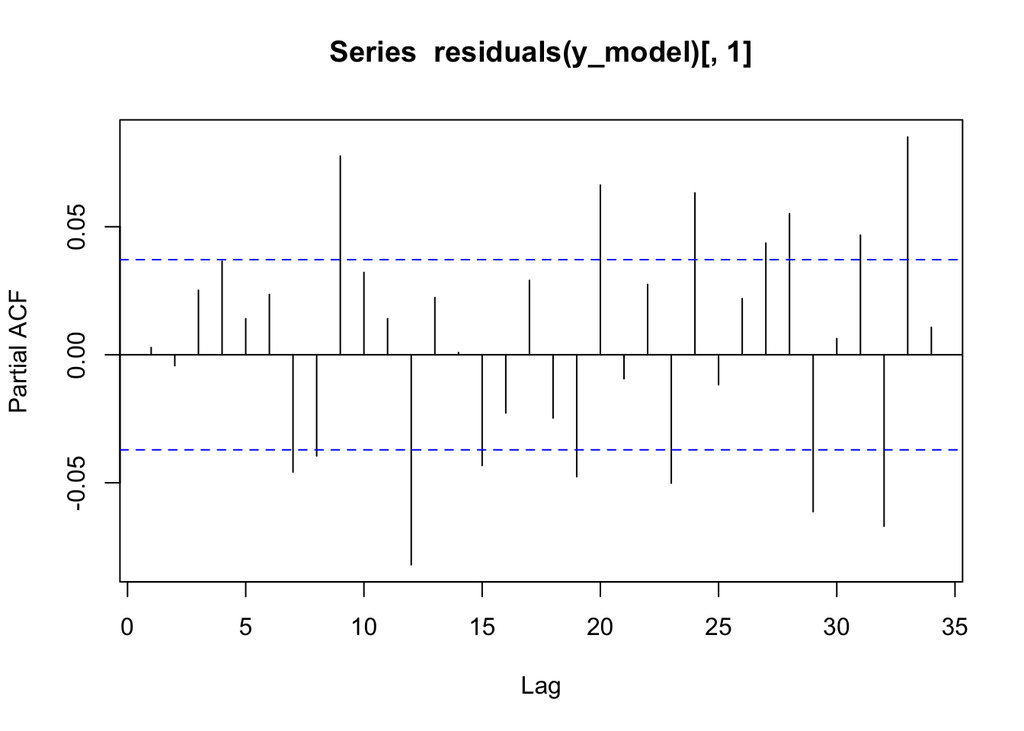

```r
pacf(residuals(y_model)[,1])
```

From our VAR model, we see that volume is dependent on past values of stock price and past values of itself, which makes sense because the stock price increases then more people get into the market to trade. The volume does not depend on lag 1 of stock price very much, which is also reasonable, since they happen at the same time. Moreover, stock price depends on its lagged value (l1) and lagged values of volume (l2 and l3). This also makes sense as the change in volume usually does not affect stock price instantaneously, but they do drive up the future stock prices if they increase. The residual plots show that there might be cycles presented, but they are more complex (i.e., we cannot spot the trend right away), so overall our VAR model fits most data.

13. Compute, plot, and interpret the respective impulse response functions.

```r
irf(y_model)
```

```
##
## Impulse response coefficients
## $BTC_ts
##         BTC_ts  volume_ts
##  [1,] 791.4978 -525110763
##  [2,] 771.6106 -350570776
##  [3,] 764.2444  391398568
##  [4,] 761.2690  -32507089
##  [5,] 754.2246   37018143
##  [6,] 755.0438  202969915
##  [7,] 752.6441  141468101
##  [8,] 749.6467  182998378
##  [9,] 748.2959  233507013
## [10,] 746.3319  240569317
## [11,] 744.3758  268000113
```

[output cut: 74 more lines]

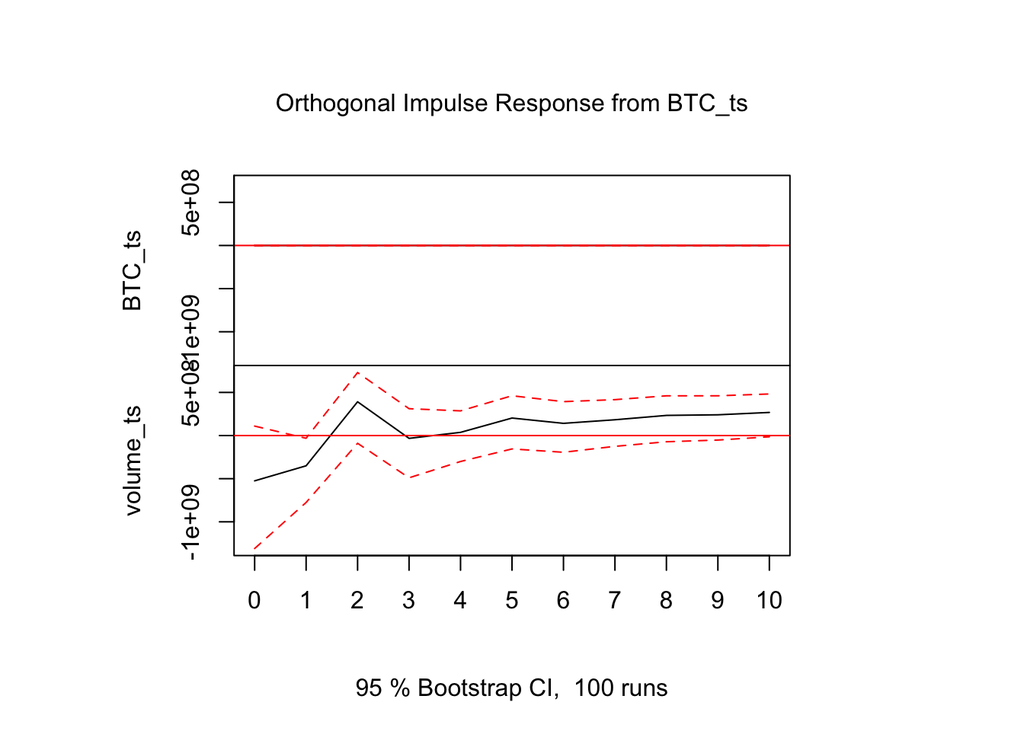

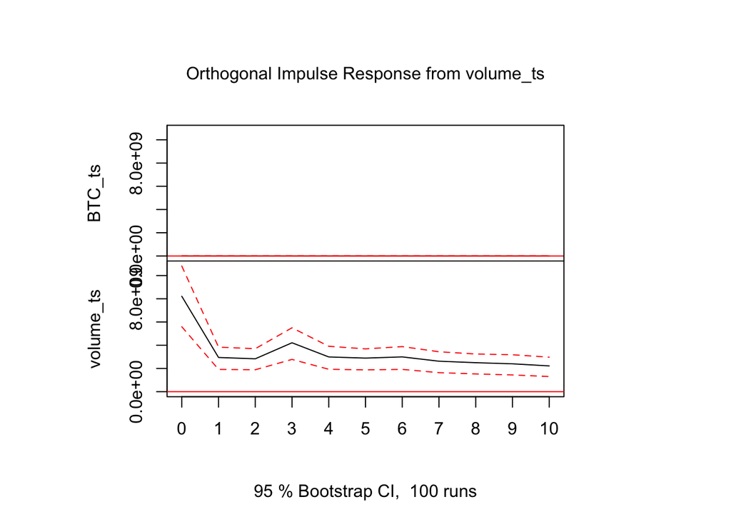

```r
plot(irf(y_model))
```

14. Perform a Granger-Causality test on your variables and discuss your results from the test.

```r
grangertest(BTC_ts ~ volume_ts, order=3)
```

|  | Res.Df | Df | F | Pr(>F) |
| --- | --- | --- | --- | --- |
| 1 | 2778 | NA | NA | NA |
| 2 | 2781 | -3 | 7.791369 | 3.529534e-05 |

The Granger causality test is a statistical hypothesis test for determining whether one time series is useful in forecasting another. The results of the test show that there are strong relationship between the two variables because the p value is less than 0.05 and statistically significant. So we can use one variable to forecast another.

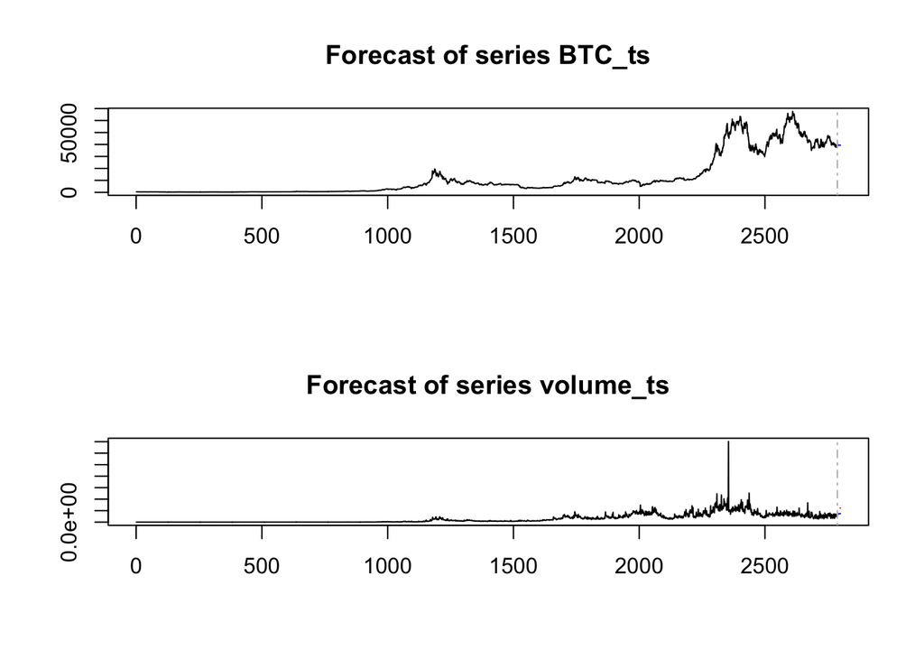

```r
var.predict = predict(object=y_model, n.ahead=12)
plot(var.predict)
```

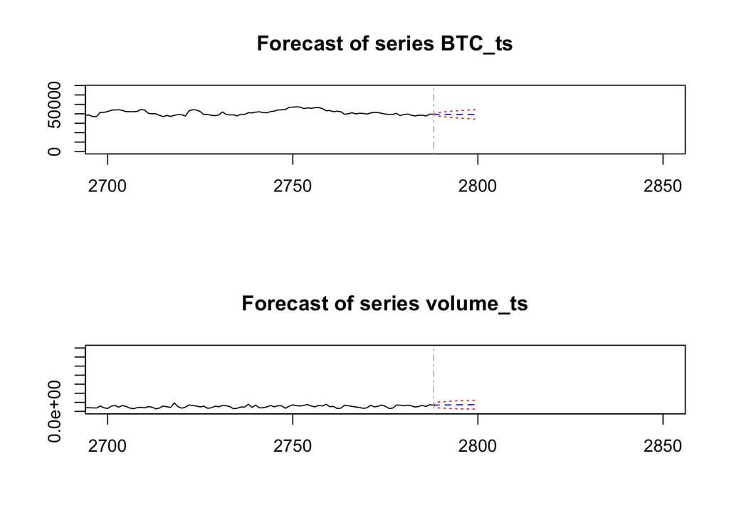

```r
plot(var.predict, xlim = c(2700,2850))
```

```r
print(var.predict$fcst)
```

```
## $BTC_ts
##           fcst    lower    upper       CI
##  [1,] 39472.69 37921.38 41024.00 1551.307
##  [2,] 39474.99 37308.33 41641.66 2166.665
##  [3,] 39461.89 36827.22 42096.57 2634.676
##  [4,] 39442.07 36414.08 42470.06 3027.993
##  [5,] 39431.71 36061.75 42801.68 3369.967
##  [6,] 39418.70 35737.78 43099.63 3680.927
##  [7,] 39405.41 35439.03 43371.80 3966.387
##  [8,] 39394.34 35163.39 43625.30 4230.955
##  [9,] 39383.08 34903.72 43862.44 4479.363
## [10,] 39372.21 34658.23 44086.18 4713.978
## [11,] 39362.11 34425.39 44298.83 4936.721
## [12,] 39352.29 34202.95 44501.63 5149.341
##
## $volume_ts
##              fcst       lower       upper          CI
##  [1,] 34749608393 18619969633 50879247153 16129638760
##  [2,] 35779595545 18633436218 52925754872 17146159327
##  [3,] 35517841373 17478829461 53556853284 18039011911
##  [4,] 35735882344 15897723338 55574041350 19838159006
##  [5,] 36065056848 15377998885 56752114811 20687057963
##  [6,] 36140926512 14687727500 57594125524 21453199012
##  [7,] 36312844414 14068368793 58557320034 22244475621
##  [8,] 36489569278 13655191255 59323947300 22834378023
##  [9,] 36611659528 13253779373 59969539684 23357880155
## [10,] 36747309971 12915759631 60578860311 23831550340
## [11,] 36875674930 12643998180 61107351679 24231676749
## [12,] 36987841199 12402253602 61573428796 24585587597
```

# III. Conclusions and Future Work

# IV. References

https://www.kaggle.com/datasets/surajjha101/analyzing-and-prediction-of-bitcoin-pricing